# Modeling California Housing Markets using Multiple Linear Regression

Joshua Zhong

12/28/2023

# 1 Abstract

This statistical report explores the dynamics of California house prices, utilizing a modified version of the California Housing data set derived from the 1990 census data. Employing methodologies such as K-means clustering, Box-Cox transformations, and bootstrapping, this analysis aims to uncover nuanced patterns and relationships within this housing market.

Key predictors that were analyzed spanned geographical location, housing characteristics, demographic details, and economic indicators of US Census block groups (i.e. neighborhoods grouped by the Census Bureau that will act as our observational unit ) and their inhabitants.

# 2 Introduction

## 2.1 Motivation

Understanding the dynamics influencing California’s house prices is essential due to its significant impact on the state’s economy. Housing affordability and market trends are critical concerns for residents, policymakers, and real estate professionals. This analysis aims to uncover the factors that shape housing prices across diverse census block groups, providing actionable insights for informed decision-making. By applying advanced statistical techniques such as Box-Cox transformations and bootstrapping, this study addresses data challenges and enhances the robustness and accuracy of findings. Utilizing the 1990 California census data offers a historical perspective, enriching our understanding of the socio-economic and spatial factors shaping the housing landscape over time.

## 2.2 Data set Description

The data set was found on Kaggle. It includes information gathered from various block groups in California during the 1990 Census. The U.S. Census Bureau uses the block group as the smallest geographical unit, typically consisting of 600 to 3000 people. Each observation in the data set represents one block group and comprises an average of 1425.5 individuals in a geographically compact area.

## 2.3 Research Question

The primary objective of this analysis is to identify the main factors influencing house prices among California census block groups. This research aims to explore the following practical questions:

- Which socioeconomic factors exhibit the strongest correlation with median house prices?
- What data transformations, if any, are necessary for accurate modeling?

This analysis will seek to explore 2 hypotheses:

- Hypothesis 1: A reduced model will perform better than the full model.
- Hypothesis 2: Distance to the ocean is negatively correlated with median house value.

# 3 Methods

This section outlines the key methodologies employed in the analysis, including multiple linear regression, K-means clustering, Box-Cox transformation, and bootstrapping.

## 3.1 Multiple Linear Regression

Multiple linear regression (MLR) is used to examine how predictors such as housing characteristics and demographic factors influence California house prices. The dependent variable is MedianHouseValue, with independent variables including median income, population, and geographic location. The initial model includes all predictors to establish a baseline before refining based on diagnostics. Key assumptions are linearity, independence of observations, homoscedasticity, and normally distributed residuals.

## 3.2 K-means Clustering

To capture the geographical variation of latitude and longitude in a more interpretable and meaningful way, K-means clustering is employed. This method groups California’s block groups into distinct geographic regions, which are used as a new categorical variable, GeoCluster. T his clustering technique allows for latitude and longitude to be useful predictors, as considering them as separate predictors is unreliable. An elbow plot is employed to determine the optimal number of clusters. The main assumption is that geographic proximity (as measured by distance) meaningfully influences house prices, and that the number of clusters adequately represents regional differences.

## 3.3 Box-Cox Transformation

Box-Cox transformation is employed to address violations of regression assumptions, particularly non-normality and heteroscedasticity of residuals. By transforming the dependent variable, MedianHouseValue, the Box-Cox method helps stabilize variance and approximate a normal distribution of residuals, improving the overall fit of the regression model. This transformation assumes that the relationship between the predictors and the dependent variable can be linearized and that the response variable is strictly positive, which holds true in this dataset.

## 3.4 Bootstrap Residuals

Bootstrapping is used to generate robust confidence intervals for the regression coefficients, especially when the assumptions of normality for residuals are violated. By resampling the dataset 1,000 times with replacement, we estimate the variability in the coefficients without relying on parametric assumptions. Bootstrapping is a flexible, non-parametric approach, with the key assumption being that the sample is representative of the population, and resampling can approximate the true sampling distribution of the model estimates.

## 3.5 Other Methods

In addition to the core methods listed above, other statistical techniques may be employed, depending on the results of the initial analyses:

1. Variance Inflation Factor (VIF): This will be used to detect multicollinearity in the multiple regression models.
2. Residual Diagnostics: Standard diagnostic plots (Q-Q plot, residuals vs. fitted, etc.) will be used to assess the validity of assumptions in the regression model.
3. Cross-Validation: If beneficial, cross-validation may be used to validate the robustness of the final model and prevent overfitting.

# 4 Exploratory Data Analysis

The original data set contains 9 independent variables and 1 dependent variable. Before proceeding with model building, it is important to explore the relationships among the variables, identify any patterns, and address potential issues like multicollinearity or irrelevant variables.

## 4.1 Data Characteristics

The dataset, originally published in Pace et al.’s 1997 paper *Sparse Spatial Autoregressions*, includes observations from the 1990 US Census of California block groups. The response variable is the median house value, with 9 predictor variables describing geographic location, housing characteristics, resident demographics, and socioeconomic factors.

## 4.2 Summary Statistics

A summary of the dataset’s key statistics is provided below:

```r
cahouses %>%
  summary() %>%
  t() %>%
  kable(format = "markdown", caption = "Summary of Data Set's Statistics", )
```

Summary of Data Set’s Statistics

| longitude | Min. :-124.3 | 1st Qu.:-121.8 | Median :-118.5 | Mean :-119.6 | 3rd Qu.:-118.0 | Max. :-114.3 | NA |
| --- | --- | --- | --- | --- | --- | --- | --- |
| latitude | Min. :32.54 | 1st Qu.:33.93 | Median :34.26 | Mean :35.63 | 3rd Qu.:37.71 | Max. :41.95 | NA |
| housing_median_age | Min. : 1.00 | 1st Qu.:18.00 | Median :29.00 | Mean :28.64 | 3rd Qu.:37.00 | Max. :52.00 | NA |
| total_rooms | Min. : 2 | 1st Qu.: 1448 | Median : 2127 | Mean : 2636 | 3rd Qu.: 3148 | Max. :39320 | NA |
| total_bedrooms | Min. : 1.0 | 1st Qu.: 296.0 | Median : 435.0 | Mean : 537.9 | 3rd Qu.: 647.0 | Max. :6445.0 | NA’s :207 |
| population | Min. : 3 | 1st Qu.: 787 | Median : 1166 | Mean : 1425 | 3rd Qu.: 1725 | Max. :35682 | NA |
| households | Min. : 1.0 | 1st Qu.: 280.0 | Median : 409.0 | Mean : 499.5 | 3rd Qu.: 605.0 | Max. :6082.0 | NA |
| median_income | Min. : 0.4999 | 1st Qu.: 2.5634 | Median : 3.5348 | Mean : 3.8707 | 3rd Qu.: 4.7432 | Max. :15.0001 | NA |
| median_house_value | Min. : 14999 | 1st Qu.:119600 | Median :179700 | Mean :206856 | 3rd Qu.:264725 | Max. :500001 | NA |
| ocean_proximity | Length:20640 | Class :character | Mode :character | NA | NA | NA | NA |

### 4.2.1 Handling Missing Values

There are 207 missing values for total_bedrooms. As such, these observations will be removed. While it’s normally not advised to remove observations due to concerns of losing information from the data, there are 20640 observations, meaning that removing 207 observations will have a very minor impact. The benefits of removing the observations with missing values outweigh the drawbacks.

```r
  cahouses <- na.omit(cahouses, cols = "total_bedrooms")
  sum(is.na(cahouses))
## [1] 0
```

### 4.2.2 Standardizing Income

Median income was converted to US Dollars to match the units of median house value.

```r
# conversion of income to USD
  cahouses$median_income <- cahouses$median_income * 10000
  summary(cahouses$median_income)
##    Min. 1st Qu.  Median    Mean 3rd Qu.    Max.
##    4999   25637   35365   38712   47440  150001
```

## 4.3 Geographic Factors

Longitude and latitude were analyzed together to identify geographic patterns, leading to the creation of geographic clusters. By doing so, longitude and latitude provide more meaningful information geographic information than if they were considered separately.

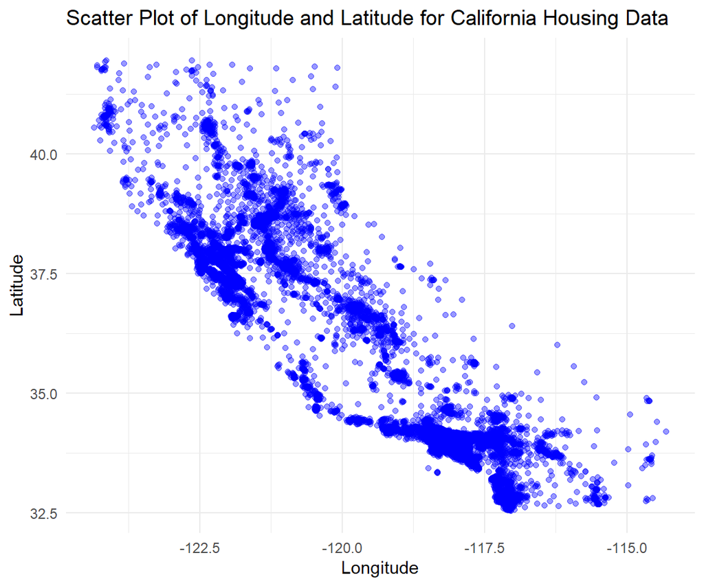

```r
ggplot(cahouses, aes(x = longitude, y = latitude)) +
  geom_point(alpha = 0.4, color = 'blue') +
  labs(title = "Scatter Plot of Longitude and Latitude for California Housing Data",
       x = "Longitude", y = "Latitude") +
  theme_minimal()
```

### 4.3.1 Creating Geographic Clusters

Before clustering longitude and latitude, we’ll create an elbow plot to help determine the optimal number of clusters.

The plot graphs the total within-cluster sum of squares (WCSS), which measures the compactness of the clusters. As the number of clusters increases, the WCSS decreases because the data points are closer to the centroids of their respective clusters. Finding this elbow allows for us to choose a K that appropriately balances model complexity and cluster compactness.

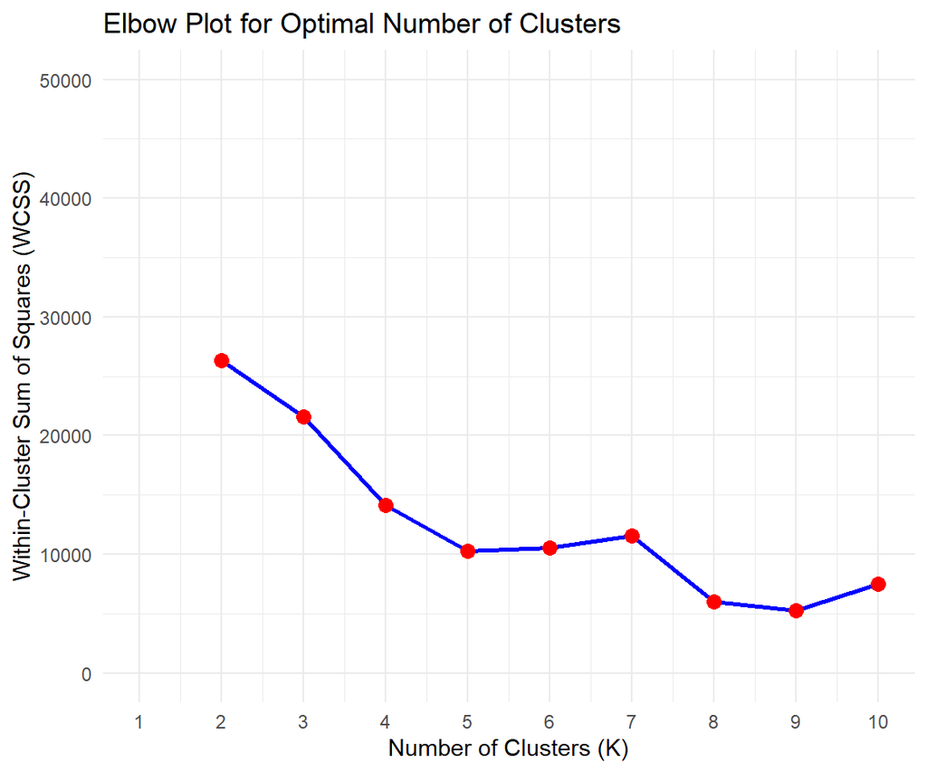

```r
set.seed(123)

# Subset the data to include only latitude and longitude
geo_data <- cahouses[, c('longitude', 'latitude')]

# Set a range of potential K values (number of clusters)
wcss <- numeric()  # Initialize an empty vector for within-cluster sum of squares

# Calculate WCSS for different numbers of clusters
for (k in 1:10) {
  kmeans_result <- kmeans(geo_data, centers = k)
  wcss[k] <- sum(kmeans_result$tot.withinss)  # Store the WCSS for each K
}

# Create the elbow plot
elbow_plot <- data.frame(K = 1:10, WCSS = wcss)

ggplot(elbow_plot, aes(x = K, y = WCSS)) +
  geom_line(color = "blue", size = 1) +
  geom_point(color = "red", size = 3) +
  labs(title = "Elbow Plot for Optimal Number of Clusters",
       x = "Number of Clusters (K)",
       y = "Within-Cluster Sum of Squares (WCSS)") +
  scale_x_continuous(breaks = seq(1, 10, by = 1)) +  # Ensure whole numbers on x-axis
  ylim(0, 50000) +  # Adjust to fit WCSS scale better
  theme_minimal()
```

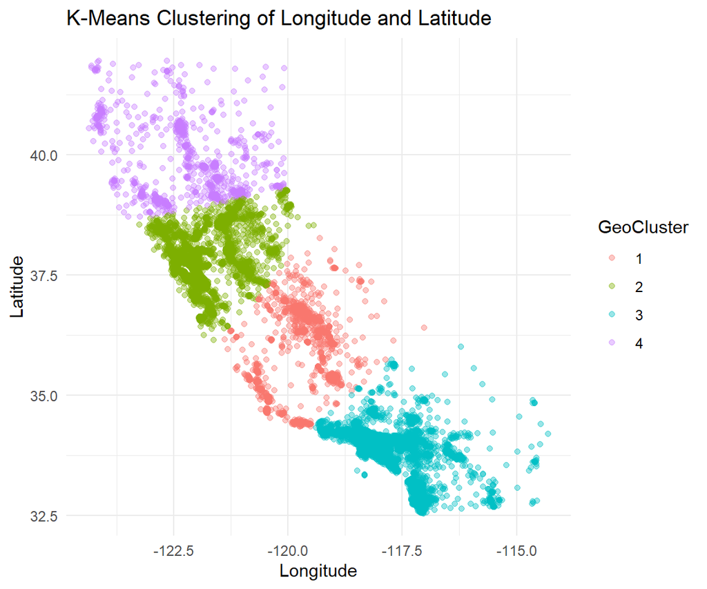

```r
# Clustering longitude and latitude into regions using k-means
set.seed(123) # Setting a seed for reproducibility
kmeans_result <- kmeans(cahouses[, c('longitude', 'latitude')], centers = 4)

# Add the cluster assignment as a new categorical variable
cahouses$GeoCluster <- as.factor(kmeans_result$cluster)

# Summarize the clustering result
table(cahouses$GeoCluster)
##
##     1     2     3     4
##  1771  6743 10913  1006

# Plot the geographic clusters
ggplot(cahouses, aes(x = longitude, y = latitude, color = GeoCluster)) +
  geom_point(alpha = 0.4) +
  labs(title = "K-Means Clustering of Longitude and Latitude",
       x = "Longitude", y = "Latitude") +
  theme_minimal()
```

### 4.3.2 Ocean proximity

OceanProximity describes whether the house is near the ocean. This is a critical factor when considering housing prices due to its strong association with real estate value.

Histograms for median house value across different levels of OceanProximity are plotted to visually investigate for any meaningful distributional differences.

[figure not shown]

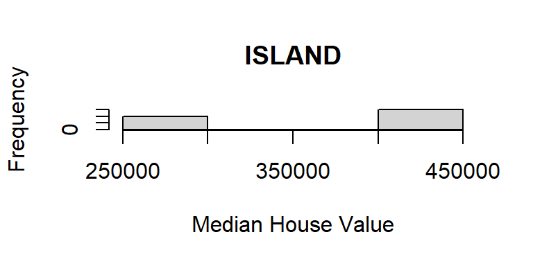

```r
par(mfrow = c(1,1))

hist(island$median_house_value, xlab = "Median House Value", main = "ISLAND" )
```

```r
anova_model <- aov(median_house_value ~ ocean_proximity, data = cahouses)
summary(anova_model)
```

```
##                    Df    Sum Sq   Mean Sq F value Pr(>F)
## ocean_proximity     4 6.479e+13 1.620e+13    1595 <2e-16 ***
## Residuals       20428 2.075e+14 1.016e+10
## ---
## Signif. codes:  0 '***' 0.001 '**' 0.01 '*' 0.05 '.' 0.1 ' ' 1
```

The Anova resulted in F(4, 20428) = 1595, p < 0.001. This means that at least one factor level differs from the others. As a result, OceanProximity is still relevant to the study at hand.

### 4.3.3 Chi-Squared Test between GeoCluster and OceanProximity

To ensure that the GeoCluster and OceanProximity variables are not confounding each other, a Chi-Squared Test of Independence is run. This test will check if there is an association between the two categorical variables. If the p-value is significant, we will need to assess the impact of using both variables in the model.

```r
geo_ocean_table <- table(cahouses$GeoCluster, cahouses$ocean_proximity)
chisq.test(geo_ocean_table)
```

```
##
##  Pearson's Chi-squared test
##
## data:  geo_ocean_table
## X-squared = 9684.5, df = 12, p-value < 2.2e-16
```

Since Χ^2(12) = 9684.5, p < 0.01 from the chi-squared test of independence, there appears to be an association between geographic cluster and ocean proximity. This concern will be addressed when candidate models are built.

## 4.4 Socioeconomic Factors

Socioeconomic factors such as population distribution, economic status, and household distributions can significantly influence median house values and will be considered as part of this study.

### 4.4.1 Median Income

A histogram of median income distribution of the 20433 observations is created.

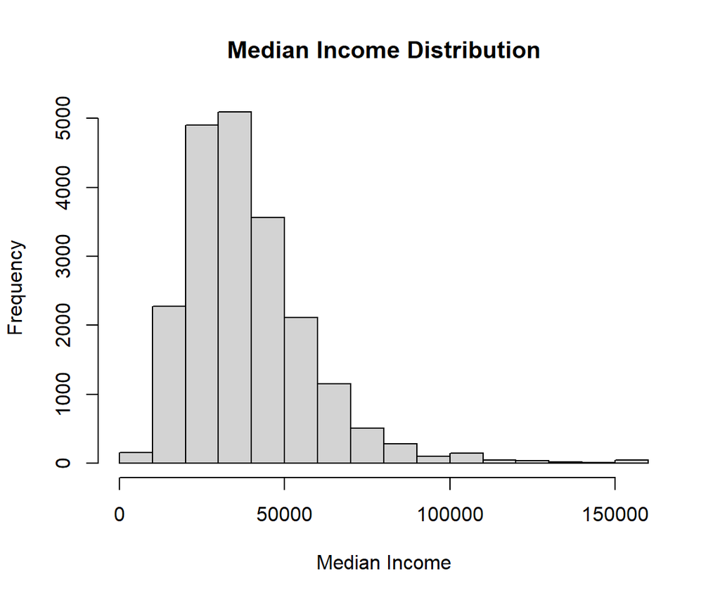

```r
# income distribution
hist(cahouses$median_income, xlab = "Median Income", main = "Median Income Distribution")
```

The distribution of median income is right-skewed, with a noticeable cap at $150001, suggesting that discretization was already performed.

```r
#proof income was pre-discretized

  sum(cahouses$median_income == 150001)
## [1] 48

  tail(sort(cahouses$median_income), 50)
##  [1] 150000 150000 150001 150001 150001 150001 150001 150001 150001 150001
## [11] 150001 150001 150001 150001 150001 150001 150001 150001 150001 150001
## [21] 150001 150001 150001 150001 150001 150001 150001 150001 150001 150001
## [31] 150001 150001 150001 150001 150001 150001 150001 150001 150001 150001
## [41] 150001 150001 150001 150001 150001 150001 150001 150001 150001 150001
```

### 4.4.2 Inhabitant Characteristics

Histograms for population and household counts were plotted, both displaying right-skewed distributions.

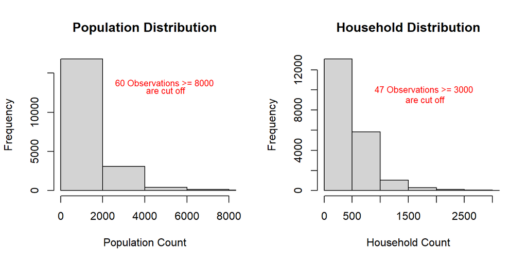

```r
#Population distribution
par(mfrow = c(1,2))
hist(cahouses$population, xlab = "Population Count", xlim = c(0, 8000), main = "Population Distribution" )
text(x = 5000, y = 15000, labels = "60 Observations >= 8000 ", col = "red", cex = 0.8, pos = 1)
text(x = 5000, y = 14000, labels = "are cut off", col = "red", cex = 0.8, pos = 1)

sum(cahouses$population >= 8000)
## [1] 60

#Household distribution
hist(cahouses$households, xlab = "Household Count", xlim = c(0, 3000), main = "Household Distribution" )
text(x = 1800, y = 11000, labels = "47 Observations >= 3000 ", col = "red", cex = 0.8, pos = 1)
text(x = 1800, y = 10000, labels = "are cut off", col = "red", cex = 0.8, pos = 1)
```

```r
sum(cahouses$households >= 3000)
## [1] 47
```

Population-dense areas, typically urban or suburban, contribute to this skew by comprising smaller geographic areas. This leads to a concentration of block groups with smaller populations and household sizes. Consequently, it is likely that a transformation will be required to correct these skews before proceeding with the analysis.

## 4.5 House Characteristics

### 4.5.1 Median House Age

The distribution of housing median age was approximately normal, with a spike at 52 years.

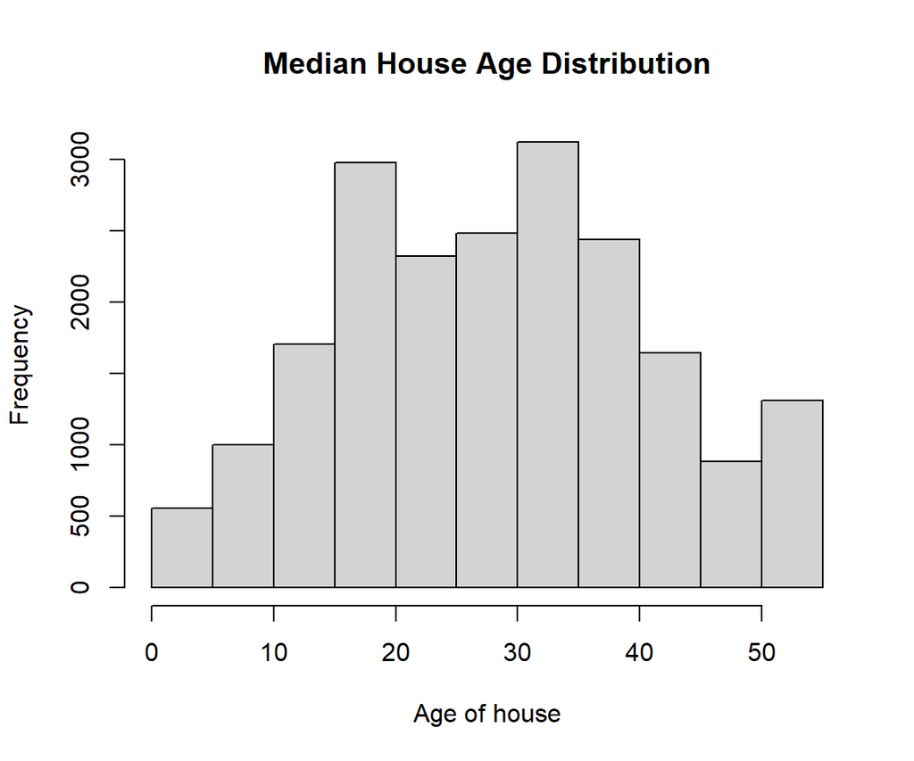

```r
# house age distribution
hist(cahouses$housing_median_age, xlab = "Age of house", main = "Median House Age Distribution" )
```

```r
sum(cahouses$housing_median_age == 52)
## [1] 1265
```

This large spike at 52 years old may suggest that the data for housing age may have been discretized since 1,265 observations are recorded at this exact age. Nonetheless, since normality is largely satisfied, no transformation is required for housing age.

### 4.5.2 Rooms and Bedrooms

Both total rooms and total bedrooms distributions were heavily right-skewed. This is likely to be because of densely populated areas.

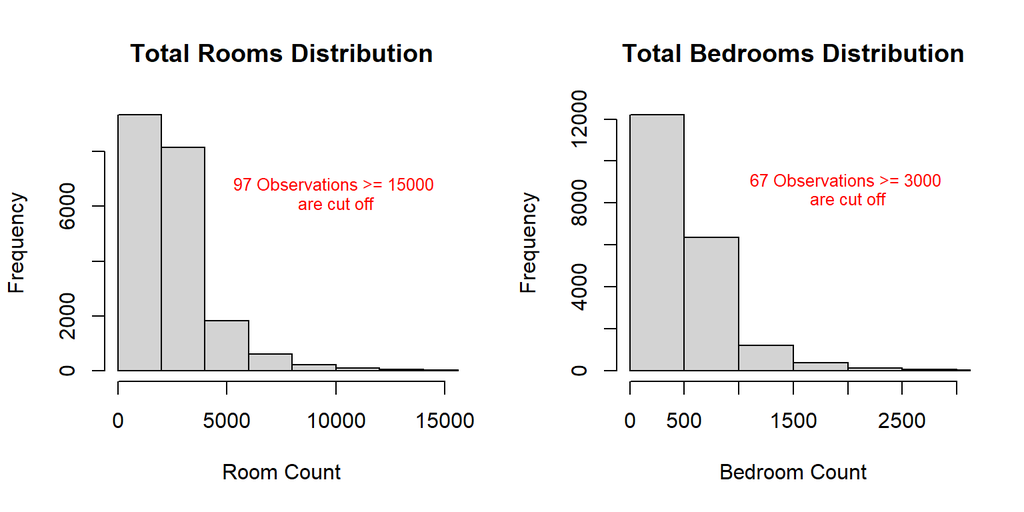

```r
# Total room distribution
par(mfrow = c(1,2))
hist(cahouses$total_rooms, xlab = "Room Count", xlim = c(0,15000), main = "Total Rooms Distribution" )
text(x = 10000, y = 7500, labels = "97 Observations >= 15000 ", col = "red", cex = 0.8, pos = 1)
text(x = 10000, y = 6800, labels = "are cut off", col = "red", cex = 0.8, pos = 1)

sum(cahouses$total_rooms >= 15000)
## [1] 97


# Total bedroom distribution
hist(cahouses$total_bedrooms, xlab = "Bedroom Count", xlim = c(0, 3000), main = "Total Bedrooms Distribution" )
text(x = 2000, y = 10000, labels = "67 Observations >= 3000 ", col = "red", cex = 0.8, pos = 1)
text(x = 2000, y = 9100, labels = "are cut off", col = "red", cex = 0.8, pos = 1)
```

```r
sum(cahouses$total_bedrooms >= 3000)
## [1] 67
```

## 4.6 Multicollinearity and Variable Selection

Multicollinearity occurs when two or more predictor variables in a model are highly correlated, which can obscure the true relationship between each predictor and the response variable. A key step before building the regression model is to check for multicollinearity among the numerical variables.

### 4.6.1 Pairwise Scatterplot

A pairwise scatterplot is used to visually inspect the relationships between numerical variables and check for highly correlated pairs. The correlation coefficients between the variables are shown on the plot, and higher correlations indicate potential issues with multicollinearity.

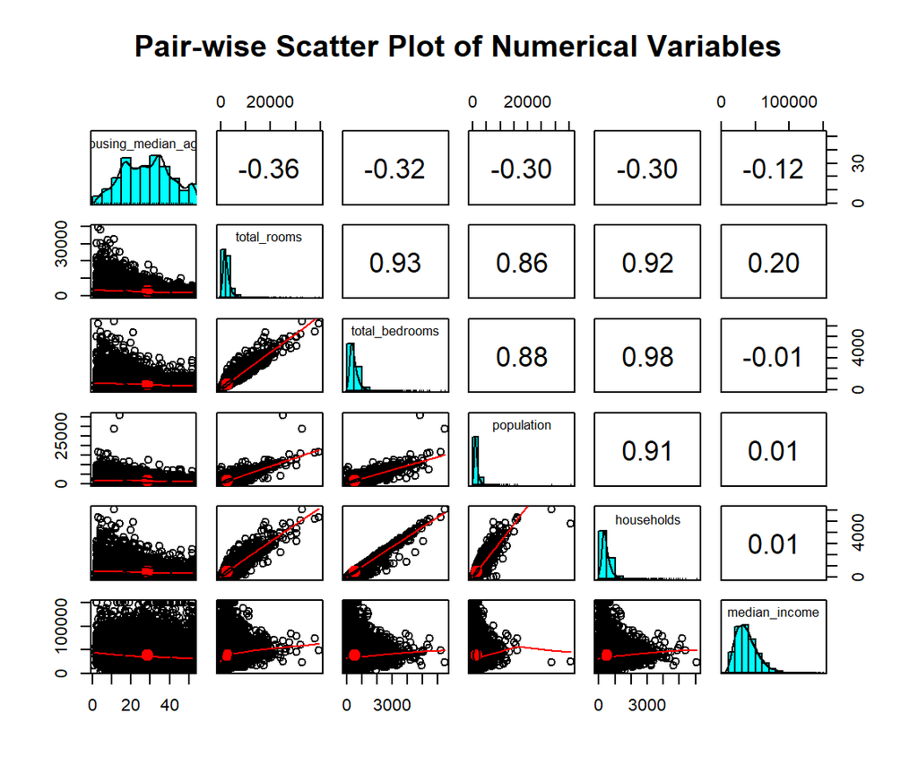

```r
pairs.panels(cahouses[, -c(1, 2, 9, 10, 11)], pch=21, main="Pair-wise Scatter Plot of Numerical Variables")
```

### 4.6.2 Variance Inflation Factor (VIF) Check

VIF values were calculated to formally detect multicollinearity.

```r
full_model <- lm(median_house_value~. - longitude - latitude, data = cahouses)
vif(full_model)
##                         GVIF Df GVIF^(1/(2*Df))
## housing_median_age  1.322156  1        1.149850
## total_rooms        12.974415  1        3.602001
## total_bedrooms     36.052098  1        6.004340
## population          6.447227  1        2.539139
## households         34.571458  1        5.879750
## median_income       1.809616  1        1.345220
## ocean_proximity     2.190419  4        1.102976
## GeoCluster          1.870925  3        1.110050
```

In examining the VIF values, Total Rooms (VIF = 12.97), Total Bedrooms (VIF = 36.05), and Households (VIF = 34.57) exhibit extremely high multicollinearity, which is consistent with our earlier visual inspection of the pairwise scatterplots. These VIF values for total rooms, total bedrooms, and households suggest multicollinearity. These issues will be addressed in the variable selection and modeling steps.

## 4.7 Outlier (Observation #15361)

One of the observations is an outlier that has significant leverage and influence on the results. Based on the observation’s longitude of -117.42 and latitude of 33.35, the observation is the Marine Corps Base Camp Pendleton. As this observation is not generalizable to non-military residences, this point will be removed.

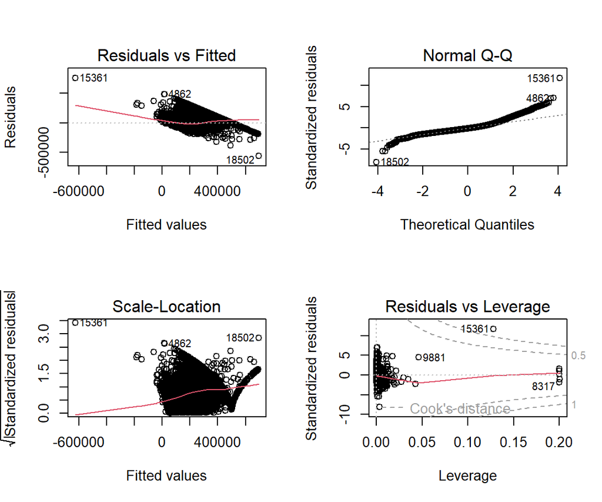

```r
par(mfrow = c(2,2))
plot(full_model)
```

```r
cahouses <- cahouses[-15213,]

#Key Note:
#Observation labeled #15361 now resides in position 15213 in the data frame because
#observations were removed
```

Removing the outlier improves our residual plots significantly:

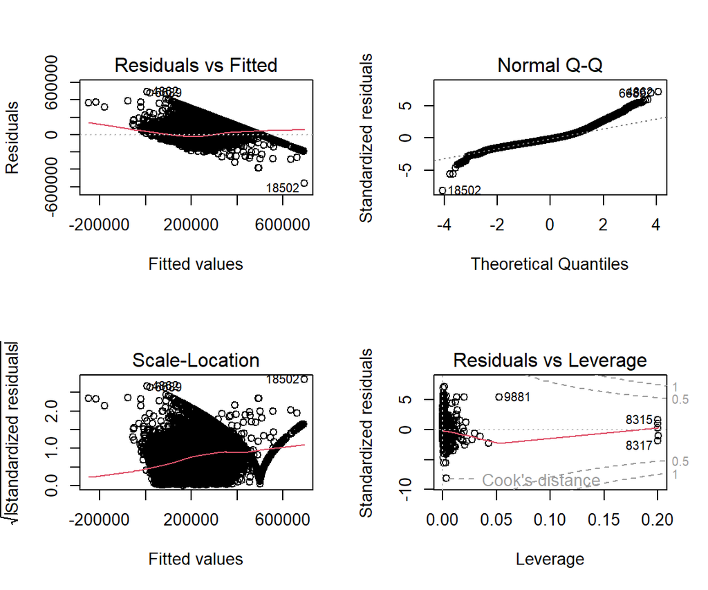

```r
full_modelout <- lm(median_house_value~. - longitude - latitude, data = cahouses)
par(mfrow = c(2,2))
plot(full_modelout)
```

# 5 Regression Modeling

After performing the exploratory data analysis and preparing the data, the next step is to develop a regression model. The aim is to build a model that not only meets statistical requirements, such as satisfying assumptions about linearity, normality, and homoscedasticity, but also provides valuable practical insights for decision-making.

```r
cahouses$ocean_proximity <- as.factor(cahouses$ocean_proximity)
cahouses$ocean_proximity <- relevel(cahouses$ocean_proximity, ref = "INLAND")
```

## 5.1 Full Model

We begin by fitting a full model with all predictors (excluding longitude and latitude, which were previously transformed into geographic clusters). This model will serve as the baseline for comparison.

```r
full_model <- lm(median_house_value ~ . - longitude - latitude, data = cahouses)

kable(round(summary(full_model)$coef, 3), caption = "Coefficient Matrix for Full Linear Model") %>%
  kable_styling(bootstrap_options = c("striped", "hover", "condensed"), full_width = F) %>%
  column_spec(1:5, width = "4cm")
```

Coefficient Matrix for Full Linear Model

|  | Estimate | Std. Error | t value | Pr(>\|t\|) |
| --- | --- | --- | --- | --- |
| (Intercept) | -45351.740 | 2453.552 | -18.484 | 0 |
| housing_median_age | 1121.265 | 44.167 | 25.387 | 0 |
| total_rooms | -5.952 | 0.800 | -7.443 | 0 |
| total_bedrooms | 74.770 | 6.903 | 10.832 | 0 |
| population | -42.330 | 1.156 | -36.629 | 0 |
| households | 86.588 | 7.515 | 11.522 | 0 |
| median_income | 3.925 | 0.034 | 114.445 | 0 |
| ocean_proximity<1H OCEAN | 66576.990 | 1370.682 | 48.572 | 0 |
| ocean_proximityISLAND | 239279.059 | 30945.062 | 7.732 | 0 |
| ocean_proximityNEAR BAY | 61752.058 | 1993.335 | 30.979 | 0 |
| ocean_proximityNEAR OCEAN | 79836.973 | 1696.757 | 47.053 | 0 |
| GeoCluster2 | 22810.173 | 1976.065 | 11.543 | 0 |
| GeoCluster3 | 13514.760 | 1923.147 | 7.027 | 0 |
| GeoCluster4 | -14180.696 | 2741.346 | -5.173 | 0 |

To assess the model, we check for any violations of regression assumptions by examining residual plots:

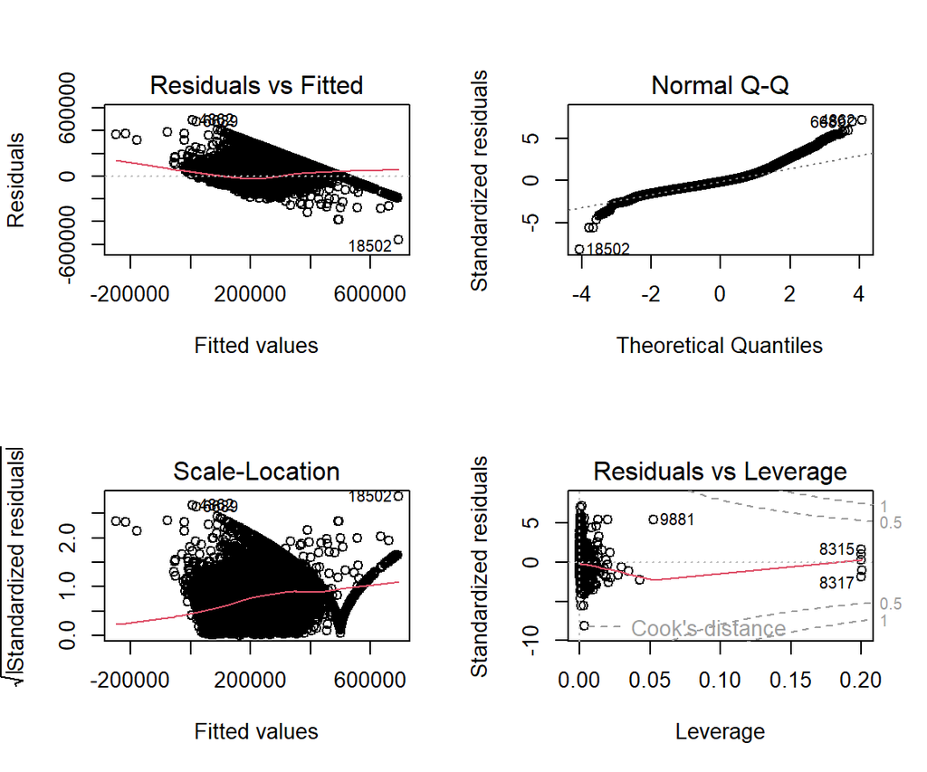

```r
par(mfrow = c(2,2))
plot(full_model)
```

## 5.2 Alternate Ocean Proximity Model

Because the Ocean Proximity seems to be imprecise, we are opting to have a candidate model that replaces the categorical Ocean Proximity variable with numeric variables that captures how close the observation is to the California Coast and 4 major Californian cities measured in kilometers.

```r
new_cahouses <- read.csv("https://raw.githubusercontent.com/JZhong01/STA321/refs/heads/main/Topic%203/California_Houses.csv")

merged_data <- merge(cahouses, new_cahouses,
    by.x = c("median_house_value", "latitude", "longitude", "total_rooms", "population"),     by.y = c("Median_House_Value", "Latitude", "Longitude", "Tot_Rooms", "Population"),
                     all.x = TRUE)

final_merged_data <- merged_data %>%
  select(median_house_value, housing_median_age, total_rooms, total_bedrooms, population, households, median_income, GeoCluster, Distance_to_coast, Distance_to_LA,
         Distance_to_SanJose, Distance_to_SanFrancisco,
         Distance_to_SanDiego)

final_merged_data$Distance_to_coast <- final_merged_data$Distance_to_coast / 1000
final_merged_data$Distance_to_LA <- final_merged_data$Distance_to_LA / 1000
final_merged_data$Distance_to_SanDiego <- final_merged_data$Distance_to_SanDiego / 1000
final_merged_data$Distance_to_SanJose <- final_merged_data$Distance_to_SanJose / 1000
final_merged_data$Distance_to_SanFrancisco <- final_merged_data$Distance_to_SanFrancisco / 1000

full_merged_model <- lm(median_house_value ~ . , data = final_merged_data)





kable(round(summary(full_merged_model)$coefficients, 3), caption = "Coefficient Matrix for Full Alternate Model") %>%
  kable_styling(bootstrap_options = c("striped", "hover", "condensed"), full_width = F) %>%
  column_spec(1:5, width = "4cm")
```

Coefficient Matrix for Full Alternate Model

|  | Estimate | Std. Error | t value | Pr(>\|t\|) |
| --- | --- | --- | --- | --- |
| (Intercept) | 154786.598 | 7985.069 | 19.385 | 0.000 |
| housing_median_age | 920.901 | 45.508 | 20.236 | 0.000 |
| total_rooms | -5.134 | 0.803 | -6.389 | 0.000 |
| total_bedrooms | 99.924 | 6.930 | 14.420 | 0.000 |
| population | -45.171 | 1.163 | -38.831 | 0.000 |
| households | 60.289 | 7.609 | 7.924 | 0.000 |
| median_income | 3.896 | 0.034 | 112.939 | 0.000 |
| GeoCluster2 | -11566.432 | 4708.263 | -2.457 | 0.014 |
| GeoCluster3 | 3712.252 | 4573.849 | 0.812 | 0.417 |
| GeoCluster4 | 39956.696 | 6048.523 | 6.606 | 0.000 |
| Distance_to_coast | -646.604 | 14.746 | -43.851 | 0.000 |
| Distance_to_LA | -120.968 | 11.723 | -10.319 | 0.000 |
| Distance_to_SanJose | -11.375 | 25.827 | -0.440 | 0.660 |
| Distance_to_SanFrancisco | -149.248 | 25.608 | -5.828 | 0.000 |
| Distance_to_SanDiego | -27.063 | 11.542 | -2.345 | 0.019 |

To assess the model, we check for any violations of regression assumptions by examining residual plots:

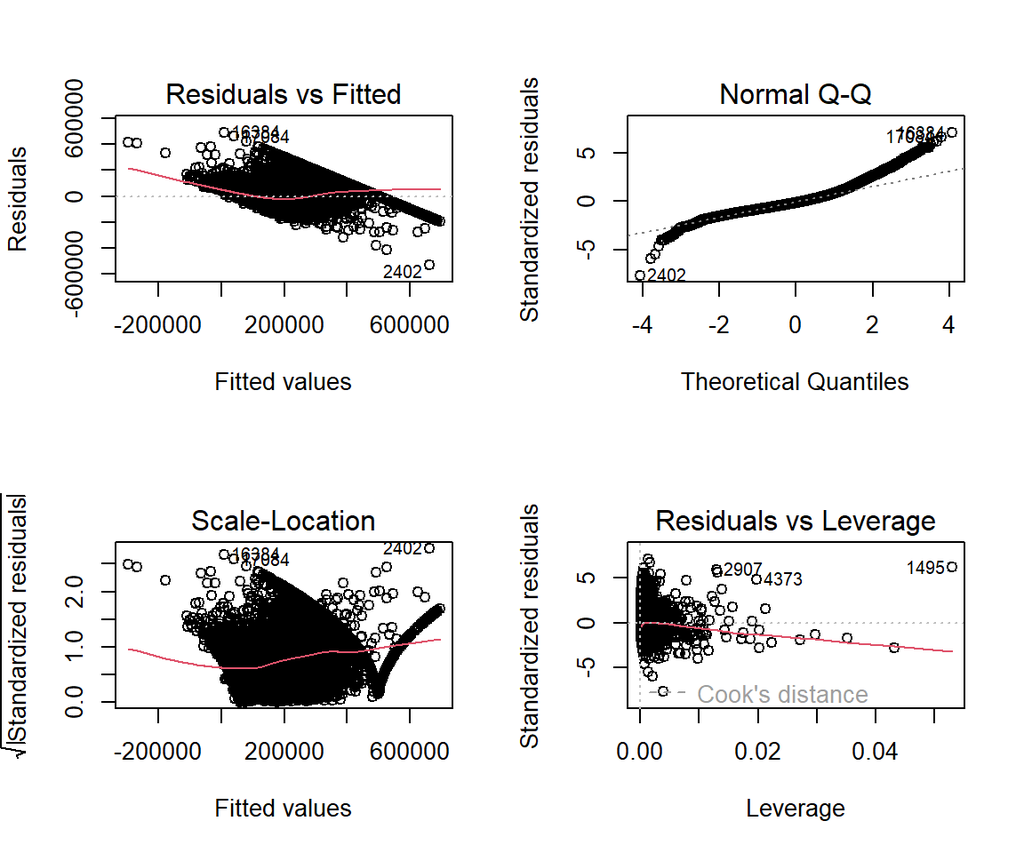

```r
par(mfrow = c(2,2))
plot(full_merged_model)
```

```r
vif(full_merged_model)
##                                GVIF Df GVIF^(1/(2*Df))
## housing_median_age         1.402773  1        1.184387
## total_rooms               13.103326  1        3.619852
## total_bedrooms            36.246130  1        6.020476
## population                 7.092286  1        2.663135
## households                35.929327  1        5.994108
## median_income              1.833799  1        1.354178
## GeoCluster               300.053561  3        2.587417
## Distance_to_coast          2.238875  1        1.496287
## Distance_to_LA            36.038039  1        6.003169
## Distance_to_SanJose      134.404601  1       11.593300
## Distance_to_SanFrancisco 175.317864  1       13.240765
## Distance_to_SanDiego      47.675617  1        6.904753
```

It appears as though GeoCluster experiences severe collinearity with multiple other variables, meaning that it’ll like be removed from the alternate model.

## 5.3 Reduced Model

Both the original and alternate full models seem to experience many issues (one of which being multicollinearity). In order to alleviate this, we’ll perform backwards stepwise regression on both.

### 5.3.1 Stepwise on Original Model

```r
library(leaps)
library(caret)


# Define the control using a 10-fold cross-validation
fitControl <- trainControl(method = "cv", number = 10)

# Define the grid of tuning parameters (number of predictors)
nvmaxGrid <- expand.grid(nvmax = seq(1, 13, by = 1))

# Set the seed for reproducibility
set.seed(123)

# Perform the backward stepwise regression with cross-validation
model.step <- train(median_house_value ~ . - latitude - longitude,
                    data = cahouses,
                    method = "leapBackward",
                    trControl = fitControl,
                    tuneGrid = nvmaxGrid)

# Display the results
print(model.step)
## Linear Regression with Backwards Selection
##
## 20432 samples
##    10 predictor
##
## No pre-processing
## Resampling: Cross-Validated (10 fold)
## Summary of sample sizes: 18388, 18389, 18389, 18389, 18388, 18389, ...
## Resampling results across tuning parameters:
##
##   nvmax  RMSE      Rsquared   MAE
##    1     83712.42  0.4742727  62605.22
##    2     82058.28  0.4948407  61132.24
##    3     79265.55  0.5286252  57929.70
##    4     74186.87  0.5869818  53787.11
##    5     74003.32  0.5890391  53657.36
##    6     71080.14  0.6208521  51455.35
##    7     69911.68  0.6333222  50790.55
##    8     69712.59  0.6354088  50582.58
##    9     69461.80  0.6380394  50443.78
##   10     69410.28  0.6385833  50393.81
##   11     69346.93  0.6392872  50277.45
##   12     69168.13  0.6411656  50125.07
##   13     69125.38  0.6416062  50169.41
##
## RMSE was used to select the optimal model using the smallest value.
## The final value used for the model was nvmax = 13.

# Summary of the stepwise regression model
summary(model.step)
## Subset selection object
## 13 Variables  (and intercept)
##                           Forced in Forced out
## housing_median_age            FALSE      FALSE
## total_rooms                   FALSE      FALSE
## total_bedrooms                FALSE      FALSE
## population                    FALSE      FALSE
## households                    FALSE      FALSE
## median_income                 FALSE      FALSE
## ocean_proximity<1H OCEAN      FALSE      FALSE
## ocean_proximityISLAND         FALSE      FALSE
## ocean_proximityNEAR BAY       FALSE      FALSE
## ocean_proximityNEAR OCEAN     FALSE      FALSE
## GeoCluster2                   FALSE      FALSE
## GeoCluster3                   FALSE      FALSE
## GeoCluster4                   FALSE      FALSE
## 1 subsets of each size up to 13
## Selection Algorithm: backward
##           housing_median_age total_rooms total_bedrooms population households
## 1  ( 1 )  " "                " "         " "            " "        " "
## 2  ( 1 )  " "                " "         " "            " "        " "
## 3  ( 1 )  " "                " "         " "            " "        " "
## 4  ( 1 )  " "                " "         " "            " "        " "
## 5  ( 1 )  " "                " "         " "            " "        "*"
## 6  ( 1 )  " "                " "         " "            "*"        "*"
## 7  ( 1 )  "*"                " "         " "            "*"        "*"
## 8  ( 1 )  "*"                " "         " "            "*"        "*"
## 9  ( 1 )  "*"                " "         " "            "*"        "*"
## 10  ( 1 ) "*"                " "         "*"            "*"        "*"
## 11  ( 1 ) "*"                " "         "*"            "*"        "*"
## 12  ( 1 ) "*"                "*"         "*"            "*"        "*"
## 13  ( 1 ) "*"                "*"         "*"            "*"        "*"
##           median_income ocean_proximity<1H OCEAN ocean_proximityISLAND
## 1  ( 1 )  "*"           " "                      " "
## 2  ( 1 )  "*"           "*"                      " "
## 3  ( 1 )  "*"           "*"                      " "
## 4  ( 1 )  "*"           "*"                      " "
## 5  ( 1 )  "*"           "*"                      " "
## 6  ( 1 )  "*"           "*"                      " "
## 7  ( 1 )  "*"           "*"                      " "
## 8  ( 1 )  "*"           "*"                      " "
## 9  ( 1 )  "*"           "*"                      " "
## 10  ( 1 ) "*"           "*"                      " "
## 11  ( 1 ) "*"           "*"                      "*"
## 12  ( 1 ) "*"           "*"                      "*"
## 13  ( 1 ) "*"           "*"                      "*"
##           ocean_proximityNEAR BAY ocean_proximityNEAR OCEAN GeoCluster2
## 1  ( 1 )  " "                     " "                       " "
## 2  ( 1 )  " "                     " "                       " "
## 3  ( 1 )  " "                     "*"                       " "
## 4  ( 1 )  "*"                     "*"                       " "
## 5  ( 1 )  "*"                     "*"                       " "
## 6  ( 1 )  "*"                     "*"                       " "
## 7  ( 1 )  "*"                     "*"                       " "
## 8  ( 1 )  "*"                     "*"                       "*"
## 9  ( 1 )  "*"                     "*"                       "*"
## 10  ( 1 ) "*"                     "*"                       "*"
## 11  ( 1 ) "*"                     "*"                       "*"
## 12  ( 1 ) "*"                     "*"                       "*"
## 13  ( 1 ) "*"                     "*"                       "*"
##           GeoCluster3 GeoCluster4
## 1  ( 1 )  " "         " "
## 2  ( 1 )  " "         " "
## 3  ( 1 )  " "         " "
## 4  ( 1 )  " "         " "
## 5  ( 1 )  " "         " "
## 6  ( 1 )  " "         " "
## 7  ( 1 )  " "         " "
## 8  ( 1 )  " "         " "
## 9  ( 1 )  "*"         " "
## 10  ( 1 ) "*"         " "
## 11  ( 1 ) "*"         " "
## 12  ( 1 ) "*"         " "
## 13  ( 1 ) "*"         "*"
```

Using 10-fold CV, we see that the optimal number of predictors is p = 13, which means no variables were removed in the stepwise model. This isn’t particularly helpful as it is the same as the original full model. In addition, even if we decided to remove 3 predictors to get a parsimonious model, we would be removing 2 dummy variables: GeoCluster4 and ocean_proximityISLAND. This would change how GeoCluster and OceanProximity would be interpreted.

As a result, we choose to disqualify this model from our candidate models.

### 5.3.2 Stepwise on Alternate Model

In our alternate model, we replace GeoCluster and OceanProximity with numeric variables that are measuring the distance to the the coast and 4 major Californian cities.

```r
# Define the control using a 10-fold cross-validation
fitControl <- trainControl(method = "cv", number = 10)

# Define the grid of tuning parameters (number of predictors)
nvmaxGrid <- expand.grid(nvmax = seq(1, 9, by = 1))

# Set the seed for reproducibility
set.seed(123)

# Perform the backward stepwise regression with cross-validation
alt.model.step <- train(median_house_value ~ . - GeoCluster,
                    data = final_merged_data,
                    method = "leapBackward",
                    trControl = fitControl,
                    tuneGrid = nvmaxGrid)

# Display the results
print(alt.model.step)
## Linear Regression with Backwards Selection
##
## 20432 samples
##    12 predictor
##
## No pre-processing
## Resampling: Cross-Validated (10 fold)
## Summary of sample sizes: 18388, 18389, 18389, 18389, 18388, 18389, ...
## Resampling results across tuning parameters:
##
##   nvmax  RMSE      Rsquared   MAE
##   1      83725.12  0.4743627  62606.62
##   2      75670.39  0.5703971  56118.68
##   3      75470.81  0.5726352  56022.26
##   4      72558.71  0.6050730  53782.85
##   5      72335.61  0.6075033  53770.73
##   6      70640.74  0.6256511  52089.54
##   7      69774.34  0.6348429  51435.28
##   8      69626.88  0.6363727  51344.19
##   9      69545.41  0.6372281  51175.76
##
## RMSE was used to select the optimal model using the smallest value.
## The final value used for the model was nvmax = 9.

# Summary of the stepwise regression model
summary(alt.model.step)
## Subset selection object
## 11 Variables  (and intercept)
##                          Forced in Forced out
## housing_median_age           FALSE      FALSE
## total_rooms                  FALSE      FALSE
## total_bedrooms               FALSE      FALSE
## population                   FALSE      FALSE
## households                   FALSE      FALSE
## median_income                FALSE      FALSE
## Distance_to_coast            FALSE      FALSE
## Distance_to_LA               FALSE      FALSE
## Distance_to_SanJose          FALSE      FALSE
## Distance_to_SanFrancisco     FALSE      FALSE
## Distance_to_SanDiego         FALSE      FALSE
## 1 subsets of each size up to 9
## Selection Algorithm: backward
##          housing_median_age total_rooms total_bedrooms population households
## 1  ( 1 ) " "                " "         " "            " "        " "
## 2  ( 1 ) " "                " "         " "            " "        " "
## 3  ( 1 ) " "                " "         "*"            " "        " "
## 4  ( 1 ) " "                " "         "*"            "*"        " "
## 5  ( 1 ) " "                " "         "*"            "*"        " "
## 6  ( 1 ) " "                " "         "*"            "*"        " "
## 7  ( 1 ) "*"                " "         "*"            "*"        " "
## 8  ( 1 ) "*"                " "         "*"            "*"        "*"
## 9  ( 1 ) "*"                " "         "*"            "*"        "*"
##          median_income Distance_to_coast Distance_to_LA Distance_to_SanJose
## 1  ( 1 ) "*"           " "               " "            " "
## 2  ( 1 ) "*"           "*"               " "            " "
## 3  ( 1 ) "*"           "*"               " "            " "
## 4  ( 1 ) "*"           "*"               " "            " "
## 5  ( 1 ) "*"           "*"               "*"            " "
## 6  ( 1 ) "*"           "*"               "*"            " "
## 7  ( 1 ) "*"           "*"               "*"            " "
## 8  ( 1 ) "*"           "*"               "*"            " "
## 9  ( 1 ) "*"           "*"               "*"            " "
##          Distance_to_SanFrancisco Distance_to_SanDiego
## 1  ( 1 ) " "                      " "
## 2  ( 1 ) " "                      " "
## 3  ( 1 ) " "                      " "
## 4  ( 1 ) " "                      " "
## 5  ( 1 ) " "                      " "
## 6  ( 1 ) "*"                      " "
## 7  ( 1 ) "*"                      " "
## 8  ( 1 ) "*"                      " "
## 9  ( 1 ) "*"                      "*"
```

Using 10-fold CV, we find that the optimal number of predictors is 9 after removing Distance_to_SanJose and total_rooms. However, by removing households and total_rooms, we greatly reduce multicollinearity at the cost of a small amount of predictive accuracy. We get the following model and its corresponding VIF values:

```r
fstep_alt_model <- lm(median_house_value ~ . - GeoCluster - Distance_to_SanJose - Distance_to_SanDiego - households - total_rooms, data = final_merged_data)

kable(round(summary(fstep_alt_model)$coefficients, 3), caption = "Coefficient Matrix for Stepwise Model") %>%
  kable_styling(bootstrap_options = c("striped", "hover", "condensed"), full_width = F) %>%
  column_spec(1:5, width = "4cm")
```

Coefficient Matrix for Stepwise Model

|  | Estimate | Std. Error | t value | Pr(>\|t\|) |
| --- | --- | --- | --- | --- |
| (Intercept) | 120426.480 | 3784.082 | 31.824 | 0 |
| housing_median_age | 1006.604 | 44.510 | 22.615 | 0 |
| total_bedrooms | 121.906 | 2.526 | 48.255 | 0 |
| population | -42.372 | 0.959 | -44.162 | 0 |
| median_income | 3.777 | 0.027 | 137.902 | 0 |
| Distance_to_coast | -627.281 | 10.937 | -57.353 | 0 |
| Distance_to_LA | -111.119 | 4.011 | -27.703 | 0 |
| Distance_to_SanFrancisco | -99.586 | 3.912 | -25.459 | 0 |

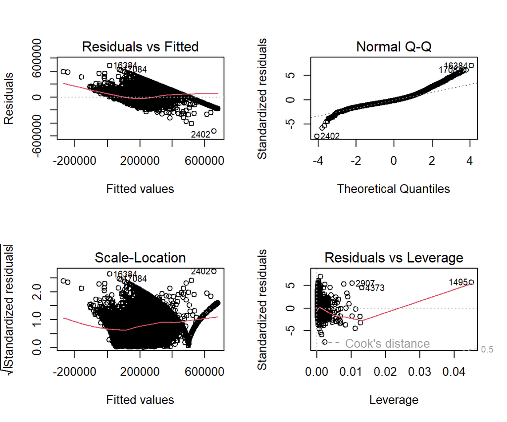

```r
par(mfrow = c(2,2))

plot(fstep_alt_model)
```

```r
vif(fstep_alt_model)
##       housing_median_age           total_bedrooms               population
##                 1.318596                 4.733375                 4.740725
##            median_income        Distance_to_coast           Distance_to_LA
##                 1.136267                 1.210310                 4.145533
## Distance_to_SanFrancisco
##                 4.019437
```

## 5.4 Box-Cox Transformation

Box-Cox transformations were conducted on both full models and the stepwise model using merged data. We are using this as it normalizes the data and reduces heteroscedasticity.

### 5.4.1 Optimal Lambda

Using Box-Cox plots, we determine the optimal lambda for each of our models.

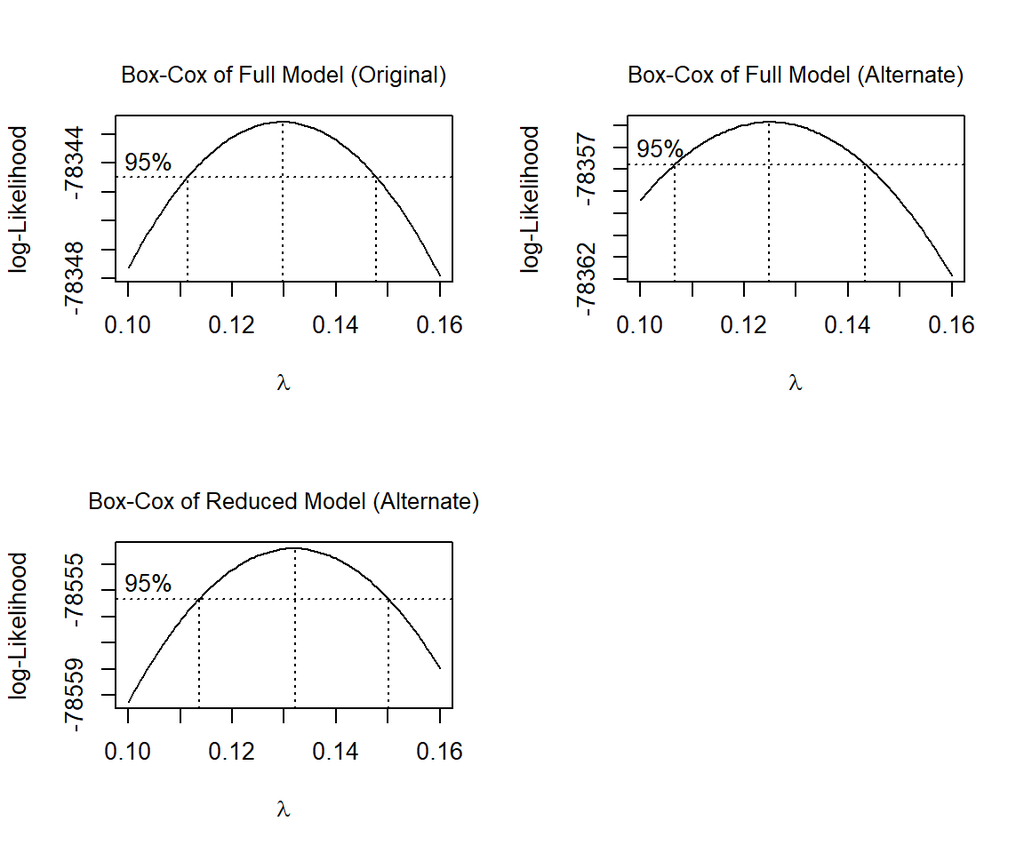

```r
par(mfrow = c(2, 2))

# Box-Cox of Full Model (Original)
boxcox_full <- boxcox(median_house_value ~ . - longitude - latitude, data = cahouses, lambda = seq(0.10, 0.16, length = 10))
mtext("Box-Cox of Full Model (Original)", side = 3, line = 1, cex = 0.8)

# Box-Cox of Full Model (Alternate)
boxcox_alt <- boxcox(median_house_value ~ . , data = final_merged_data, lambda = seq(0.10, 0.16, length = 10))
mtext("Box-Cox of Full Model (Alternate)", side = 3, line = 1, cex = 0.8)

# Box-Cox of Reduced Model (Alternate)
boxcox_step_alt <- boxcox(median_house_value ~ . - GeoCluster - Distance_to_SanJose - Distance_to_SanDiego - households - total_rooms, data = final_merged_data, lambda = seq(0.10, 0.16, length = 10))
mtext("Box-Cox of Reduced Model (Alternate)", side = 3, line = 1, cex = 0.8)
```

Based off the plots, we determine that lambda is around 0.12 - 0.13. We will now transform our response variables to the power of our respective lambdas.

### 5.4.2 Applying Box-Cox Transformation

```r
lambda_full <- 0.13
lambda_alt <- 0.125
lambda_step_alt <- 0.13


#Add transformed response variables

cahouses$transformed_house_value <- (cahouses$median_house_value^lambda_full - 1) / lambda_full

final_merged_data$alt_transformed_house_value <- (final_merged_data$median_house_value^lambda_alt - 1) / lambda_alt

final_merged_data$step_transformed_house_value <- (final_merged_data$median_house_value^lambda_step_alt - 1) / lambda_step_alt


#Refit models with transformed responses

boxcox_full_model <- lm(transformed_house_value ~ . - longitude - latitude - median_house_value, data = cahouses)

boxcox_alt_model <- lm(alt_transformed_house_value ~ . - step_transformed_house_value - median_house_value , data = final_merged_data)

boxcox_step_alt_model <- lm(step_transformed_house_value ~ . - GeoCluster - Distance_to_SanJose - Distance_to_SanDiego - households - total_rooms - median_house_value - alt_transformed_house_value, data = final_merged_data)


# Summary of the Box-Cox transformed models
kable(round(summary(boxcox_full_model)$coefficients, 5), caption = "Coefficient Matrix for Box-Cox Transformed Full Model") %>%
  kable_styling(bootstrap_options = c("striped", "hover", "condensed"), full_width = F) %>%
  column_spec(1:5, width = "4cm")
```

Coefficient Matrix for Box-Cox Transformed Full Model

|  | Estimate | Std. Error | t value | Pr(>\|t\|) |
| --- | --- | --- | --- | --- |
| (Intercept) | 23.34124 | 0.05530 | 422.05109 | 0.00000 |
| housing_median_age | 0.01413 | 0.00100 | 14.19395 | 0.00000 |
| total_rooms | -0.00006 | 0.00002 | -3.23043 | 0.00124 |
| total_bedrooms | 0.00112 | 0.00016 | 7.22836 | 0.00000 |
| population | -0.00095 | 0.00003 | -36.38216 | 0.00000 |
| households | 0.00218 | 0.00017 | 12.88396 | 0.00000 |
| median_income | 0.00008 | 0.00000 | 105.08588 | 0.00000 |
| ocean_proximity<1H OCEAN | 2.11095 | 0.03090 | 68.32465 | 0.00000 |
| ocean_proximityISLAND | 5.62816 | 0.69752 | 8.06885 | 0.00000 |
| ocean_proximityNEAR BAY | 1.80579 | 0.04493 | 40.19056 | 0.00000 |
| ocean_proximityNEAR OCEAN | 2.27427 | 0.03825 | 59.46457 | 0.00000 |
| GeoCluster2 | 1.27202 | 0.04454 | 28.55817 | 0.00000 |
| GeoCluster3 | 0.94838 | 0.04335 | 21.87783 | 0.00000 |
| GeoCluster4 | -0.31599 | 0.06179 | -5.11383 | 0.00000 |

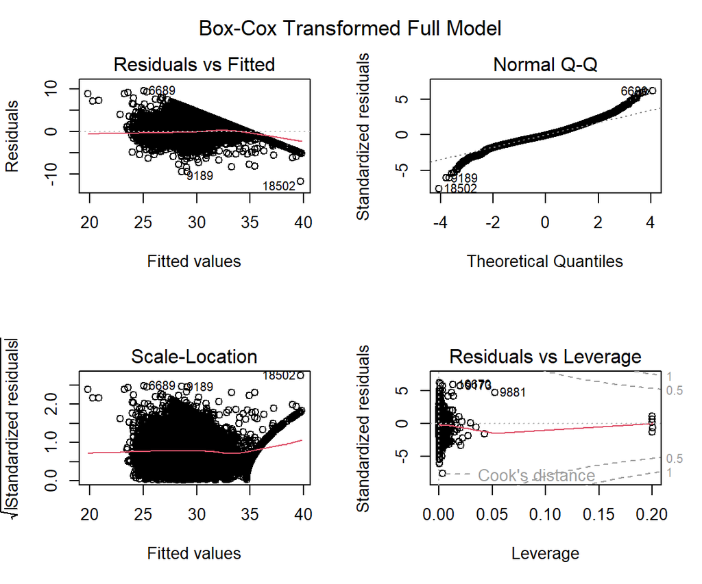

```r
# RA Full Model
par(mfrow = c(2, 2))
plot(boxcox_full_model, which = 1)
plot(boxcox_full_model, which = 2)
plot(boxcox_full_model, which = 3)
plot(boxcox_full_model, which = 5)
mtext("Box-Cox Transformed Full Model", side = 3, line = -2, outer = TRUE, cex = 1.1)
```

```r
kable(round(summary(boxcox_alt_model)$coefficients, 5), caption = "Coefficient Matrix for Box-Cox Transformed Full Alternate Model") %>%
  kable_styling(bootstrap_options = c("striped", "hover", "condensed"), full_width = F) %>%
  column_spec(1:5, width = "4cm")
```

Coefficient Matrix for Box-Cox Transformed Full Alternate Model

|  | Estimate | Std. Error | t value | Pr(>\|t\|) |
| --- | --- | --- | --- | --- |
| (Intercept) | 28.39053 | 0.16943 | 167.56452 | 0.00000 |
| housing_median_age | 0.00722 | 0.00097 | 7.47939 | 0.00000 |
| total_rooms | -0.00004 | 0.00002 | -2.41866 | 0.01559 |
| total_bedrooms | 0.00176 | 0.00015 | 11.95690 | 0.00000 |
| population | -0.00095 | 0.00002 | -38.58912 | 0.00000 |
| households | 0.00132 | 0.00016 | 8.17305 | 0.00000 |
| median_income | 0.00008 | 0.00000 | 104.02122 | 0.00000 |
| GeoCluster2 | 0.33725 | 0.09990 | 3.37581 | 0.00074 |
| GeoCluster3 | 0.51164 | 0.09705 | 5.27195 | 0.00000 |
| GeoCluster4 | 1.37702 | 0.12834 | 10.72944 | 0.00000 |
| Distance_to_coast | -0.01829 | 0.00031 | -58.46847 | 0.00000 |
| Distance_to_LA | -0.00368 | 0.00025 | -14.78465 | 0.00000 |
| Distance_to_SanJose | 0.00052 | 0.00055 | 0.94982 | 0.34221 |
| Distance_to_SanFrancisco | -0.00486 | 0.00054 | -8.94939 | 0.00000 |
| Distance_to_SanDiego | -0.00095 | 0.00024 | -3.88589 | 0.00010 |

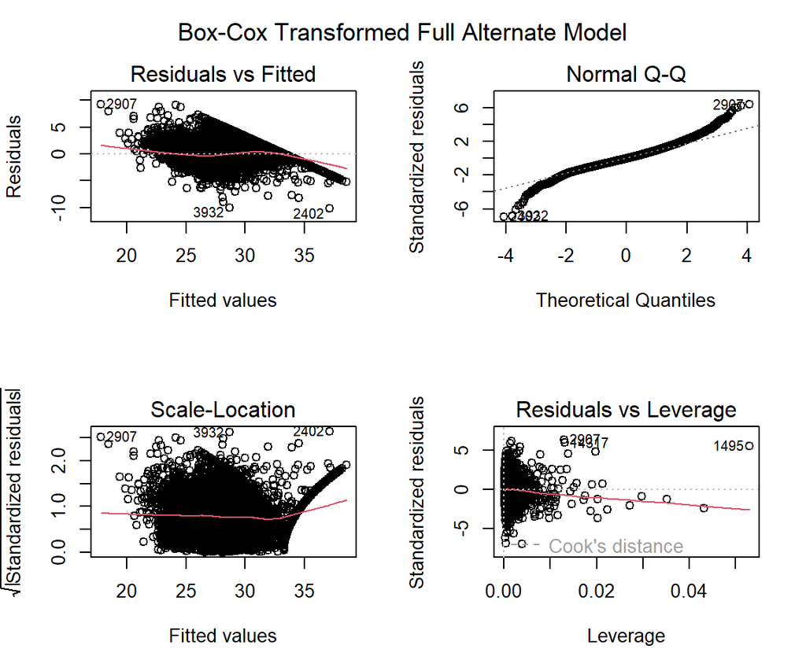

```r
# RA Alternate Full Model
par(mfrow = c(2, 2))
plot(boxcox_alt_model, which = 1)
plot(boxcox_alt_model, which = 2)
plot(boxcox_alt_model, which = 3)
plot(boxcox_alt_model, which = 5)
mtext("Box-Cox Transformed Full Alternate Model", side = 3, line = -2, outer = TRUE, cex = 1.1)
```

```r
kable(round(summary(boxcox_step_alt_model)$coefficients, 5), caption = "Coefficient Matrix for Box-Cox Transformed Stepwise Reduced Alternate Model") %>%
  kable_styling(bootstrap_options = c("striped", "hover", "condensed"), full_width = F) %>%
  column_spec(1:5, width = "4cm")
```

Coefficient Matrix for Box-Cox Transformed Stepwise Reduced Alternate Model

|  | Estimate | Std. Error | t value | Pr(>\|t\|) |
| --- | --- | --- | --- | --- |
| (Intercept) | 28.70177 | 0.08536 | 336.24828 | 0 |
| housing_median_age | 0.01029 | 0.00100 | 10.24895 | 0 |
| total_bedrooms | 0.00271 | 0.00006 | 47.49125 | 0 |
| population | -0.00092 | 0.00002 | -42.50808 | 0 |
| median_income | 0.00008 | 0.00000 | 130.45886 | 0 |
| Distance_to_coast | -0.02086 | 0.00025 | -84.53653 | 0 |
| Distance_to_LA | -0.00329 | 0.00009 | -36.40281 | 0 |
| Distance_to_SanFrancisco | -0.00287 | 0.00009 | -32.51476 | 0 |

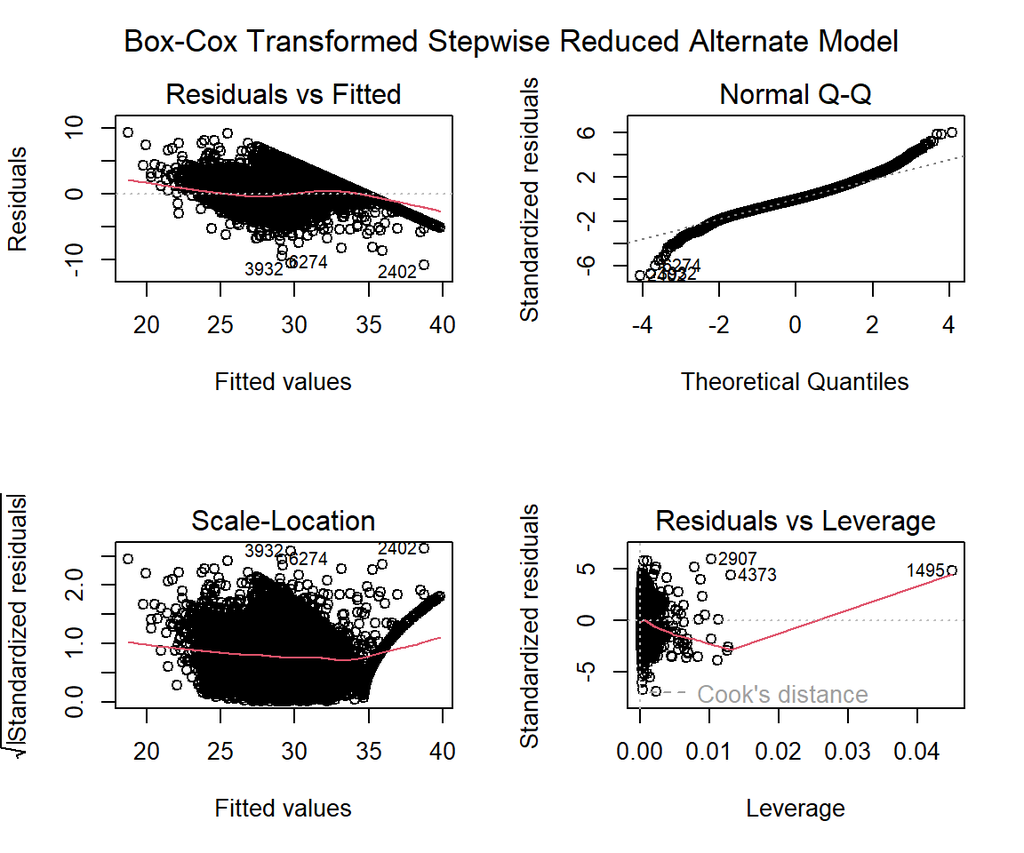

```r
# RA Stepwise Reduced Alternate Model
par(mfrow = c(2, 2))
plot(boxcox_step_alt_model, which = 1)
plot(boxcox_step_alt_model, which = 2)
plot(boxcox_step_alt_model, which = 3)
plot(boxcox_step_alt_model, which = 5)
mtext("Box-Cox Transformed Stepwise Reduced Alternate Model", side = 3, line = -2, outer = TRUE, cex = 1.1)
```

The transformed models demonstrated an improved fit, indicated by the residual plots showing more stable variance and better adherence to the assumptions of normality and homoscedasticity.

# 6 Evaluating Candidate Models

To evaluate the candidate models, we will assess their performance using various goodness-of-fit metrics, including the Adjusted R-squared, AIC (Akaike Information Criterion), BIC (Bayesian Information Criterion), and RMSE (Root Mean Squared Error). Additionally, we’ll validate the models and check for assumptions.

## 6.1 Goodness of Fit Measures

Goodness-of-fit measures help us understand how well our models capture the variability in the data. Here are the results for the candidate models:

```r
select=function(m){ # m is an object: model
 e = m$resid                           # residuals
 n0 = length(e)                        # sample size
 SSE=(m$df)*(summary(m)$sigma)^2       # sum of squared error
 R.sq=summary(m)$r.squared             # Coefficient of determination: R square!
 R.adj=summary(m)$adj.r                # Adjusted R square
 MSE=(summary(m)$sigma)^2              # square error
 Cp=(SSE/MSE)-(n0-2*(n0-m$df))         # Mellow's p
 AIC=n0*log(SSE)-n0*log(n0)+2*(n0-m$df)          # Akaike information criterion
 SBC=n0*log(SSE)-n0*log(n0)+(log(n0))*(n0-m$df)  # Schwarz Bayesian Information criterion
 X=model.matrix(m)                     # design matrix of the model
 H=X%*%solve(t(X)%*%X)%*%t(X)          # hat matrix
 d=e/(1-diag(H))
 PRESS=t(d)%*%d   # predicted residual error sum of squares (PRESS)- a cross-validation measure
 tbl = as.data.frame(cbind(SSE=SSE, R.sq=R.sq, R.adj = R.adj, Cp = Cp, AIC = AIC, SBC = SBC, PRD = PRESS))
 names(tbl)=c("SSE", "R.sq", "R.adj", "Cp", "AIC", "SBC", "PRESS")
 tbl = round(tbl, 2)
 tbl
 }




output <- rbind(select(full_model), select(full_merged_model), select(fstep_alt_model), select(boxcox_full_model), select(boxcox_alt_model), select(boxcox_step_alt_model))

row.names(output) <- c("Full Original", "Full Alternate", "Stepwise Alternate", "Box-Cox Full Original", "Box-Cox Full Alternate", "Box-Cox Stepwise Alternate" )

# kable(output, caption = "Goodness-of-fit Measures of Candidate Models")

kable(round(output, 3), caption = "Goodness-of-fit Measures of Candidate Models") %>%
  kable_styling(bootstrap_options = c("striped", "hover", "condensed"), full_width = F) %>%
  column_spec(1:5, width = "4cm")
```

Goodness-of-fit Measures of Candidate Models

|  | SSE | R.sq | R.adj | Cp | AIC | SBC | PRESS |
| --- | --- | --- | --- | --- | --- | --- | --- |
| Full Original | 9.751980e+13 | 0.64 | 0.64 | 14 | 455380.03 | 455490.97 | 9.771863e+13 |
| Full Alternate | 9.764104e+13 | 0.64 | 0.64 | 15 | 455407.41 | 455526.28 | 9.784915e+13 |
| Stepwise Alternate | 9.940472e+13 | 0.63 | 0.63 | 8 | 455759.18 | 455822.58 | 9.952681e+13 |
| Box-Cox Full Original | 4.954728e+04 | 0.67 | 0.67 | 14 | 18127.18 | 18238.13 | 4.964645e+04 |
| Box-Cox Full Alternate | 4.396004e+04 | 0.67 | 0.67 | 15 | 15684.56 | 15803.43 | 4.406047e+04 |
| Box-Cox Stepwise Alternate | 5.058050e+04 | 0.67 | 0.67 | 8 | 18536.87 | 18600.27 | 5.064489e+04 |

From these results, the **Box-Cox Full Alternate** model emerges as the best candidate. This model has the lowest AIC, SBC, and PRESS values, indicating a better overall fit and predictive performance compared to the other models.

## 6.2 Multicollinearity Consideration

However, it is important to note that the **Box-Cox Full Alternate** model may suffer from multicollinearity. Multicollinearity implies that while the model as a whole may predict well, interpreting individual coefficients can be problematic due to high correlations between the predictor variables. This can lead to unstable estimates and make it difficult to understand the effect of each variable independently.

To address this, if we prioritize a more parsimonious model that mitigates multicollinearity, the **Box-Cox Stepwise Alternate** model would be a better choice. This model simplifies the predictor set, making it easier to interpret the coefficients individually.

## 6.3 Best Model: Box-Cox Full Alternate

Given the superior performance of the **Box-Cox Full Alternate** model, we present its coefficient matrix and residual analysis below.

### 6.3.1 Coefficient Matrix

```r
kable(round(summary(boxcox_alt_model)$coefficients, 5), caption = "Coefficient Matrix of Best Model") %>%
  kable_styling(bootstrap_options = c("striped", "hover", "condensed"), full_width = F) %>%
  column_spec(1:5, width = "4cm")
```

Coefficient Matrix of Best Model

|  | Estimate | Std. Error | t value | Pr(>\|t\|) |
| --- | --- | --- | --- | --- |
| (Intercept) | 28.39053 | 0.16943 | 167.56452 | 0.00000 |
| housing_median_age | 0.00722 | 0.00097 | 7.47939 | 0.00000 |
| total_rooms | -0.00004 | 0.00002 | -2.41866 | 0.01559 |
| total_bedrooms | 0.00176 | 0.00015 | 11.95690 | 0.00000 |
| population | -0.00095 | 0.00002 | -38.58912 | 0.00000 |
| households | 0.00132 | 0.00016 | 8.17305 | 0.00000 |
| median_income | 0.00008 | 0.00000 | 104.02122 | 0.00000 |
| GeoCluster2 | 0.33725 | 0.09990 | 3.37581 | 0.00074 |
| GeoCluster3 | 0.51164 | 0.09705 | 5.27195 | 0.00000 |
| GeoCluster4 | 1.37702 | 0.12834 | 10.72944 | 0.00000 |
| Distance_to_coast | -0.01829 | 0.00031 | -58.46847 | 0.00000 |
| Distance_to_LA | -0.00368 | 0.00025 | -14.78465 | 0.00000 |
| Distance_to_SanJose | 0.00052 | 0.00055 | 0.94982 | 0.34221 |
| Distance_to_SanFrancisco | -0.00486 | 0.00054 | -8.94939 | 0.00000 |
| Distance_to_SanDiego | -0.00095 | 0.00024 | -3.88589 | 0.00010 |

Since our model underwent a Box-Cox transformation, this affects the coefficients in the final coefficient matrix. With a $\lambda$ = 0.125, this transforms the dependent variable with the following Box-Cox transformation:

$\lambda$ = 0.125 transforms the dependent variable, which in this case is the median house value. The transformed model coefficients should be interpreted in the context of this transformation.

The general form of the Box-Cox transformation is:

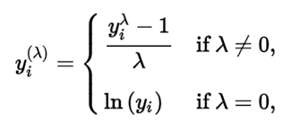

This means that the the response variable is now ((median house value)^0.125 - 1) / 0.125 and that each coefficient relates to this new response variable.

### 6.3.2 Residual Analysis

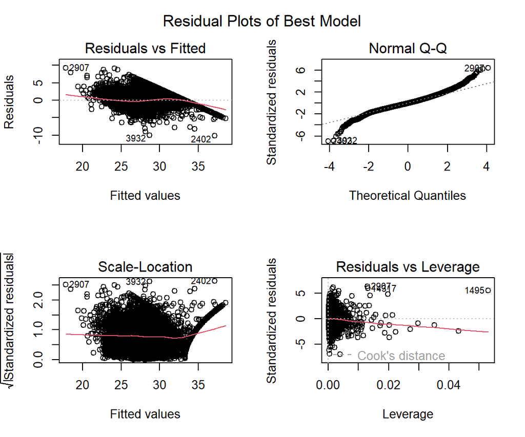

```r
par(mfrow = c(2, 2))
plot(boxcox_alt_model, which = 1)
plot(boxcox_alt_model, which = 2)
plot(boxcox_alt_model, which = 3)
plot(boxcox_alt_model, which = 5)
mtext("Residual Plots of Best Model", side = 3, line = -2, outer = TRUE, cex = 1.1)
```

# 7 Conclusion

## 7.2 Drawbacks and Future Improvements

While the Box-Cox Full Alternate model addresses many of the issues present in the original model, it comes with several limitations:

- **Multicollinearity**: The model exhibits a staggeringly high multicollinearity, which can inflate standard errors and lead to unreliable estimates for regression coefficients. Addressing multicollinearity through techniques like ridge regression or principal component analysis could enhance the model’s reliability.
- **Interpretability of Coefficients**: The coefficients of the Box-Cox transformed model are more challenging to interpret compared to models using untransformed data. Future work could explore partial transformations or alternative methods to improve interpretability without sacrificing model performance.
- **Model Complexity and Interactions**: The simplification of the model to improve interpretability meant that potential interactions between variables were not thoroughly analyzed. Future models could include interaction terms to capture more complex relationships between predictors.
- **Predictive Power**: Although the Box-Cox Full Alternate model achieved the best PRESS score, indicating good goodness of fit, we did not use cross-validation or extensive bootstrapping to thoroughly evaluate its robustness. Implementing these techniques in future analyses could provide a more comprehensive assessment of the model’s predictive power and its generalizability to new data.

## 7.3 Applications of Final Model

The Box-Cox Full Alternate model is useful for predicting housing prices in California based on the 1990 US Census data. This model can serve as a benchmark for future census results in California, allowing for comparative time series analysis to evaluate the evolving impact of certain predictors on housing prices over time.

However, it is recommended that this model be used with caution due to minor violations of regression assumptions. While bootstrap methods and transformations have addressed some of these issues, the model may still be less accurate at the extremes of the data. Additionally, the discretization of the underlying data before analysis could impact the results and should be considered in future applications.

Future research could focus on addressing the limitations identified in this study. Techniques such as ridge regression to mitigate multicollinearity, exploring alternative transformations to improve coefficient interpretability, and incorporating interaction terms for a more comprehensive model are potential avenues for improvement. By continuously refining the model, its predictive accuracy and practical applicability can be enhanced, providing valuable insights into the factors influencing housing prices in California.

# 8 References

Wang, H.(2018). *housing.csv*[Data set]. https://www.kaggle.com/code/harrywang/housing-price-prediction/input?select=housing.csv

Palacios, F. S.(2021). *California_Houses.csv*[Data set]. https://www.kaggle.com/datasets/fedesoriano/california-housing-prices-data-extra-features?resource=download

O’Reilly Media (2017). *California Housing*. GitHub. https://github.com/ageron/handson-ml/blob/master/datasets/housing/housing.csv

GPS coordinates, latitude and longitude with interactive maps. GPS coordinates, latitude and longitude with interactive Maps. (2023). https://www.gps-coordinates.net/

Frees, E. W. (2009). Regression Modeling with Actuarial and Financial Applications, 465–489. https://doi.org/10.1017/cbo9780511814372

Raj, P. (2023, July 1). Residual vs fitted graph in R. Stack Overflow. https://stackoverflow.com/questions/76605232/residual-vs-fitted-graph-in-r